# MLOps Projekt

### Detaillierte Beschreibung aller Spalten mit möglichen Werten

**1. age (Alter)**

- Typ: Numerisch
- Beschreibung: Das Alter der Person in Jahren (integer-Wert)

**2. workclass (Art der Beschäftigung)**

- Typ: Kategorisch
- Beschreibung: Gibt an, in welcher Art von Organisation die Person arbeitet
- **Mögliche Werte:**

Private -> Privatunternehmen  
Self-emp-not-inc -> Selbstständig (nicht eingetragenes Unternehmen)  
Self-emp-inc -> Selbstständig (eingetragenes Unternehmen)  
Federal-gov -> Bundesregierung  
Local-gov -> Kommunale Regierung  
State-gov -> Landesregierung  
Without-pay -> Unbezahlt arbeitend  
Never-worked -> Noch nie gearbeitet

**3. fnlwgt (Final Weight)**

- Typ: Numerisch
- Beschreibung: Eine Gewichtungsvariable, die angibt, wie viele Personen in der Bevölkerung der Stichprobe entsprechen.

**4. education (Bildungsabschluss)**

- Typ: Kategorisch
- Beschreibung: Höchster Bildungsabschluss der Person
- **Mögliche Werte:**

Preschool -> Vorschule  
1st-4th -> 1. bis 4. Schuljahr  
5th-6th -> 5. bis 6. Schuljahr  
7th-8th -> 7. bis 8. Schuljahr  
9th -> 9. Schuljahr  
10th -> 10. Schuljahr  
11th -> 11. Schuljahr  
12th -> 12. Schuljahr  
HS-grad -> High-School-Abschluss  
Some-college -> Teilweise Hochschule  
Assoc-acdm -> Associate Degree (akademisch)  
Assoc-voc -> Associate Degree (beruflich)  
Bachelors -> Bachelor-Abschluss  
Masters -> Master-Abschluss  
Doctorate -> Doktortitel (PhD)  
Prof-school -> Berufsschule

**5. educational-num (Bildungsjahre, numerisch)**

- Typ: Numerisch
- Beschreibung: Die Anzahl der abgeschlossenen Schuljahre. Diese Spalte entspricht education, aber in numerischer Form (z. B. 16 Jahre für ein PhD)

**6. marital-status (Familienstand)**

- Typ: Kategorisch
- Beschreibung: Familienstand der Person
- **Mögliche Werte:**

Married-civ-spouse -> Verheiratet (zivilrechtlich)  
Married-AF-spouse -> Verheiratet mit einer Person im aktiven Militärdienst  
Divorced -> Geschieden  
Never-married -> Noch nie verheiratet  
Separated -> Getrennt lebend  
Widowed -> Verwitwet  
Married-spouse-absent -> Verheiratet, aber getrennt lebend

**7. occupation (Berufsfeld)**

- Typ: Kategorisch
- Beschreibung: Die Art der beruflichen Tätigkeit
- **Mögliche Werte:**

Tech-support -> Technischer Support  
Craft-repair -> Handwerks- und Reparaturberufe  
Other-service -> Andere Dienstleistungen  
Sales -> Vertrieb / Verkauf  
Exec-managerial -> Führungskräfte & Management  
Prof-specialty -> Akademische Berufe (z. B. Ärzte, Ingenieure)  
Handlers-cleaners -> Handwerker & Reinigungskräfte  
Machine-op-inspct -> Maschinenführer & Inspektoren  
Adm-clerical -> Verwaltung & Büroarbeit  
Farming-fishing -> Landwirtschaft & Fischerei  
Transport-moving -> Transport & Logistik  
Priv-house-serv -> Haushaltsdienstleistungen  
Protective-serv -> Schutz- & Sicherheitsberufe (Polizei, Feuerwehr)  
Armed-Forces -> Streitkräfte / Militär

**8. relationship (Beziehung im Haushalt)**

- Typ: Kategorisch
- Beschreibung: Die Rolle der Person innerhalb des Haushalts
- **Mögliche Werte:**

Wife -> Ehefrau  
Husband -> Ehemann  
Own-child -> Eigenes Kind  
Unmarried -> Unverheiratet  
Other-relative -> Anderer Verwandter  
Not-in-family -> Kein Familienmitglied (z. B. Mitbewohner)

**9. race (Ethnische Zugehörigkeit)**

- Typ: Kategorisch
- Beschreibung: Ethnische Zugehörigkeit der Person
- **Mögliche Werte:**

White -> Weiß  
Black -> Schwarz  
Asian-Pac-Islander -> Asiatisch / Pazifikinseln  
Amer-Indian-Eskimo -> Amerikanische Ureinwohner / Inuit  
Other -> Andere

**10. gender (Geschlecht)**

- Typ: Kategorisch
- **Mögliche Werte:**

Male -> Männlich  
Female -> Weiblich

**11. capital-gain (Kapitalgewinne)**

- Typ: Numerisch
- Beschreibung: Kapitalgewinne in US-Dollar aus Investitionen oder anderen Quellen

**12. capital-loss (Kapitalverluste)**

- Typ: Numerisch
- Beschreibung: Kapitalverluste in US-Dollar

**13. hours-per-week (Arbeitsstunden pro Woche)**

- Typ: Numerisch
- Beschreibung: Durchschnittliche Arbeitsstunden pro Woche

**14. native-country (Herkunftsland)**

- Typ: Kategorisch
- Beschreibung: Das Geburtsland der Person
- **Beispiele:**

United-States -> Vereinigte Staaten  
Mexico -> Mexiko  
Germany -> Deutschland  
Canada -> Kanada  
India -> Indien  
China -> China  
Philippines -> Philippinen  
England -> England  
Other -> Andere Länder

**15. income (Zielvariable)**

- Typ: Kategorisch
- Beschreibung: Einkommensklasse der Person
- **Mögliche Werte:**

"<=50K" -> Einkommen beträgt 50.000 USD oder weniger  
">50K" -> Einkommen beträgt mehr als 50.000 USD

#### Bibliotheken laden

```python
import pandas as pd
import numpy as np
import matplotlib.pyplot as plt
import seaborn as sns
```

#### Datensatz laden

```python
df = pd.read_csv("adult.csv")
df.head()
```

|  | age | workclass | fnlwgt | education | educational-num | marital-status | occupation | relationship | race | gender | capital-gain | capital-loss | hours-per-week | native-country | income |
| --- | --- | --- | --- | --- | --- | --- | --- | --- | --- | --- | --- | --- | --- | --- | --- |
| 0 | 25 | Private | 226802 | 11th | 7 | Never-married | Machine-op-inspct | Own-child | Black | Male | 0 | 0 | 40 | United-States | <=50K |
| 1 | 38 | Private | 89814 | HS-grad | 9 | Married-civ-spouse | Farming-fishing | Husband | White | Male | 0 | 0 | 50 | United-States | <=50K |
| 2 | 28 | Local-gov | 336951 | Assoc-acdm | 12 | Married-civ-spouse | Protective-serv | Husband | White | Male | 0 | 0 | 40 | United-States | >50K |
| 3 | 44 | Private | 160323 | Some-college | 10 | Married-civ-spouse | Machine-op-inspct | Husband | Black | Male | 7688 | 0 | 40 | United-States | >50K |
| 4 | 18 | ? | 103497 | Some-college | 10 | Never-married | ? | Own-child | White | Female | 0 | 0 | 30 | United-States | <=50K |

#### Überblick über die Daten

```python
# Allgemeine Infos über den Datensatz
df.info()

# Statistische Übersicht für numerische Spalten
df.describe()

# Prüfen auf fehlende Werte
df.isnull().sum()
```

```
<class 'pandas.core.frame.DataFrame'>
RangeIndex: 48842 entries, 0 to 48841
Data columns (total 15 columns):
 #   Column           Non-Null Count  Dtype
---  ------           --------------  -----
 0   age              48842 non-null  int64
 1   workclass        48842 non-null  object
 2   fnlwgt           48842 non-null  int64
 3   education        48842 non-null  object
 4   educational-num  48842 non-null  int64
 5   marital-status   48842 non-null  object
 6   occupation       48842 non-null  object
 7   relationship     48842 non-null  object
 8   race             48842 non-null  object
 9   gender           48842 non-null  object
 10  capital-gain     48842 non-null  int64
 11  capital-loss     48842 non-null  int64
 12  hours-per-week   48842 non-null  int64
 13  native-country   48842 non-null  object
 14  income           48842 non-null  object
dtypes: int64(6), object(9)
memory usage: 5.6+ MB
```

```
age                0
workclass          0
fnlwgt             0
education          0
educational-num    0
marital-status     0
occupation         0
relationship       0
race               0
gender             0
capital-gain       0
capital-loss       0
hours-per-week     0
native-country     0
income             0
dtype: int64
```

#### Einkommensverteilung visualisieren

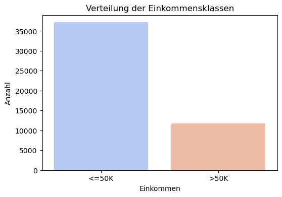

```python
plt.figure(figsize=(6,4))
sns.countplot(data=df, x="income", hue="income", palette="coolwarm", legend=False)
plt.title("Verteilung der Einkommensklassen")
plt.xlabel("Einkommen")
plt.ylabel("Anzahl")
plt.show()
```

**Erkenntnisse aus der Einkommensverteilung**

Die Visualisierung zeigt die Verteilung der Einkommensklassen. Dabei wurden zwei Einkommensgruppen untersucht:

- "<=50K": Einkommen ≤ 50.000 USD pro Jahr
- ">50K": Einkommen > 50.000 USD pro Jahr

Wichtige Beobachtungen:

- Unbalancierte Klassenverteilung: Die Mehrheit der Personen verdient ≤50.000 USD pro Jahr (über 35.000 Personen). Nur eine vergleichsweise kleine Gruppe (rund 10.000 Personen) verdient mehr als 50.000 USD jährlich.

#### Altersverteilung nach Einkommensklasse

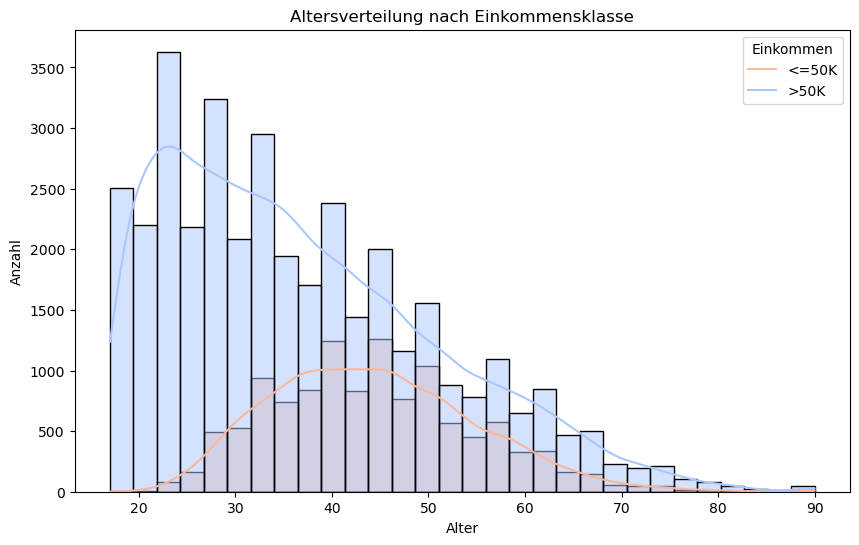

```python
# Einkommensvariable als String sicherstellen
df["income"] = df["income"].astype(str)

plt.figure(figsize=(10,6))
sns.histplot(data=df, x="age", hue="income", kde=True, bins=30, palette="coolwarm")

# Manuelle Legende
plt.legend(title="Einkommen", labels=["<=50K", ">50K"])

plt.title("Altersverteilung nach Einkommensklasse")
plt.xlabel("Alter")
plt.ylabel("Anzahl")
plt.show()
```

**Erkenntnisse aus der Altersverteilung nach Einkommensklasse**

Diese Visualisierung zeigt die Altersverteilung der Personen in Abhängigkeit von ihrer Einkommensklasse (<=50K vs. >50K).

Wichtige Beobachtungen:

1. Jüngere Personen verdienen größtenteils weniger als 50K USD
- In den Altersgruppen von 20 bis ca. 35 Jahren dominiert die Einkommensklasse <=50K
- Das deutet darauf hin, dass viele jüngere Menschen noch nicht genug Berufserfahrung oder Bildungsabschlüsse haben, um in die höhere Einkommensklasse (>50K) zu gelangen.
2. Personen mit hohem Einkommen sind meist älter
- Die Anzahl der Personen mit Einkommen über 50K USD nimmt mit dem Alter zu, insbesondere ab 35–40 Jahren
- Das könnte daran liegen, dass Menschen mit mehr Berufserfahrung, höherer Bildung oder in besser bezahlten Führungspositionen in diese Altersgruppe fallen
3. Ab 50 Jahren nimmt die Anzahl beider Einkommensklassen ab
- Die Anzahl der Personen im Datensatz nimmt ab 50 Jahren deutlich ab
- Dies könnte darauf hinweisen, dass ältere Menschen sich langsam aus dem Arbeitsmarkt zurückziehen (z. B. Rente)
- Trotzdem gibt es noch eine nennenswerte Anzahl an Personen über 50 mit Einkommen >50K, was auf gut bezahlte Fachkräfte oder Führungskräfte hindeutet
4. Verteilung der höheren Einkommen ist glatter und breiter verteilt
- Während die <=50K-Gruppe einen starken Peak in den 20ern hat, ist die >50K-Gruppe flacher und gleichmäßiger verteilt
- Dies zeigt, dass hohes Einkommen nicht an ein bestimmtes Alter gebunden ist, sondern eher durch andere Faktoren wie Beruf, Bildung und Erfahrung beeinflusst wird

#### Arbeitsstunden pro Woche nach Einkommensklasse

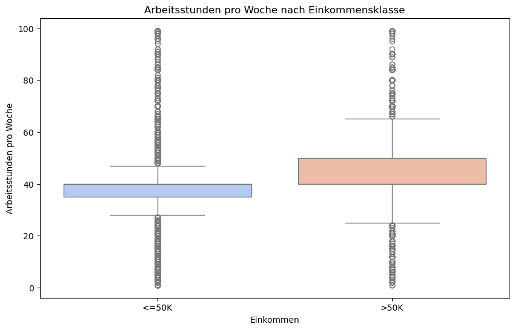

```python
plt.figure(figsize=(10,6))
sns.boxplot(data=df, x="income", y="hours-per-week", hue="income", palette="coolwarm")
plt.title("Arbeitsstunden pro Woche nach Einkommensklasse")
plt.xlabel("Einkommen")
plt.ylabel("Arbeitsstunden pro Woche")
plt.show()
```

**Erkenntnisse aus der Verteilung der Arbeitsstunden pro Woche nach Einkommensklasse**

Diese Boxplot-Visualisierung zeigt die Arbeitsstunden pro Woche für Personen in den Einkommensklassen <=50K und >50K.

#### Berufliche Verteilung nach Einkommensklasse

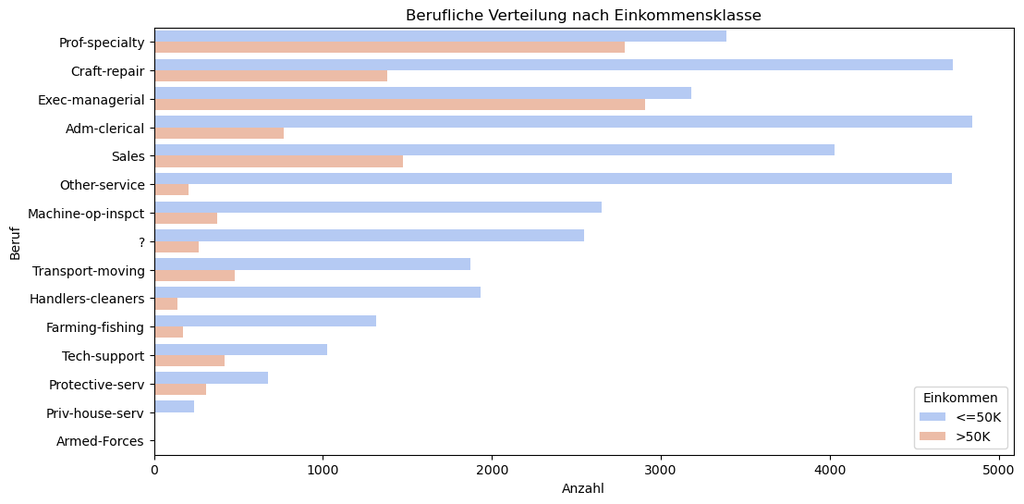

```python
plt.figure(figsize=(12,6))
sns.countplot(y="occupation", data=df, hue="income", order=df["occupation"].value_counts().index, palette="coolwarm")
plt.title("Berufliche Verteilung nach Einkommensklasse")
plt.xlabel("Anzahl")
plt.ylabel("Beruf")
plt.legend(title="Einkommen")
plt.show()
```

**Erkenntnisse aus der beruflichen Verteilung nach Einkommensklasse**

Diese Visualisierung zeigt die Verteilung der verschiedenen Berufe im Datensatz, aufgeteilt nach Einkommensklasse (<=50K vs. >50K).

Wichtige Beobachtungen:

1. Bestimmte Berufe sind stärker mit hohem Einkommen verbunden
- Die Berufe "Exec-managerial" (Führungskräfte & Management) und "Prof-specialty" (Akademische Berufe, z.B. Ärzte, Ingenieure) haben einen hohen Anteil an Personen mit einem Einkommen von über 50K USD
- Dies deutet darauf hin, dass hochqualifizierte oder leitende Positionen eine höhere Wahrscheinlichkeit für ein Einkommen über 50K haben
2. Viele Berufe sind überwiegend in der <=50K-Kategorie
- Berufe wie "Other-service" (sonstige Dienstleistungen), "Handlers-cleaners" (Handwerker & Reinigungskräfte), "Transport-moving" (Transport & Logistik), "Farming-fishing" (Landwirtschaft & Fischerei) sind überwiegend in der Einkommensklasse <=50K vertreten
- Das zeigt, dass diese Berufe in der Regel geringere Löhne haben und es schwieriger ist, in die höhere Einkommensklasse (>50K) zu kommen
3. Unbekannte oder fehlende Berufe (?)
- Es gibt eine hohe Anzahl von Personen mit einem unbekannten Beruf (?)
- Es ist unklar, ob diese Personen arbeitslos sind, in Übergangsphasen oder ob Daten fehlen
- Falls nötig, könnte diese Kategorie in der Datenbereinigung gesondert betrachtet werden
4. Berufe mit einer relativ ausgeglichenen Verteilung
- Einige Berufe wie "Craft-repair" (Handwerk & Reparatur) und "Tech-support" (Technischer Support) haben sowohl eine große Anzahl in <=50K, aber auch einige in >50K, was darauf hindeutet, dass in diesen Bereichen höhere Löhne mit mehr Erfahrung oder Spezialisierung möglich sind

#### Geschlechterverteilung nach Einkommensklasse

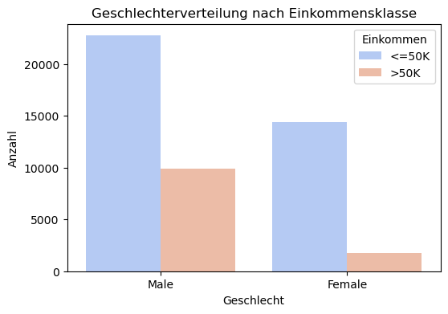

```python
plt.figure(figsize=(6,4))
sns.countplot(x="gender", data=df, hue="income", palette="coolwarm")
plt.title("Geschlechterverteilung nach Einkommensklasse")
plt.xlabel("Geschlecht")
plt.ylabel("Anzahl")
plt.legend(title="Einkommen")
plt.show()
```

**Erkenntnisse aus der Geschlechterverteilung nach Einkommensklasse**

Diese Visualisierung zeigt die Verteilung von Männern und Frauen im Datensatz in Bezug auf die beiden Einkommensklassen (<=50K und >50K).

Wichtige Beobachtungen:

1. Männer verdienen häufiger mehr als 50K USD als Frauen
- Der Anteil der Männer mit einem Einkommen über 50K USD ist deutlich höher als der der Frauen
- Dies könnte auf Faktoren wie Berufswahl, Erfahrung, Arbeitsstunden oder geschlechtsspezifische Unterschiede in der Bezahlung zurückzuführen sein
2. Mehr Frauen sind in der <=50K-Kategorie als in >50K
- Die Mehrheit der Frauen fällt in die <=50K-Kategorie, und nur ein sehr kleiner Teil hat ein Einkommen über 50K
- Dies könnte darauf hindeuten, dass Frauen häufiger in Berufen mit niedrigerem Einkommen oder in Teilzeitstellen arbeiten
3. Es gibt insgesamt mehr Männer als Frauen im Datensatz
- Sowohl in der <=50K- als auch in der >50K-Kategorie gibt es mehr Männer als Frauen
- Dies könnte darauf hinweisen, dass der Datensatz weniger Frauen als Männer erfasst oder dass Frauen im betrachteten Arbeitsmarkt insgesamt unterrepräsentiert sind

#### Herkunftsland nach Einkommensklasse

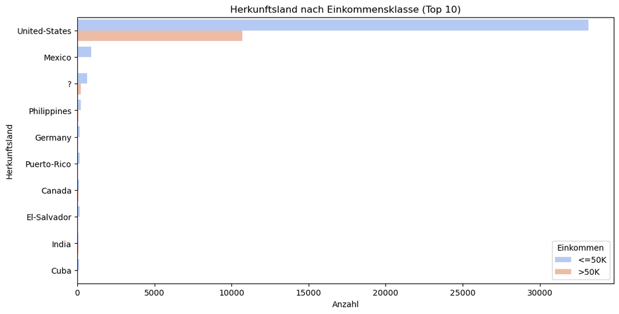

```python
plt.figure(figsize=(12,6))
sns.countplot(y="native-country", data=df, hue="income", order=df["native-country"].value_counts().index[:10], palette="coolwarm")
plt.title("Herkunftsland nach Einkommensklasse (Top 10)")
plt.xlabel("Anzahl")
plt.ylabel("Herkunftsland")
plt.legend(title="Einkommen", loc="lower right")
plt.show()
```

**Erkenntnisse aus der Einkommensverteilung nach Herkunftsland**

Diese Visualisierung zeigt die Verteilung der Einkommensklassen (<=50K und >50K) basierend auf dem Herkunftsland der Personen.

Wichtige Beobachtungen:

1. Die Mehrheit der Personen stammt aus den USA
- Die große Mehrheit der Personen im Datensatz stammt aus den Vereinigten Staaten
- Sowohl die <=50K- als auch die >50K-Kategorie sind dort stark vertreten, jedoch gibt es wesentlich mehr Personen mit niedrigerem Einkommen (<=50K), was den allgemeinen Trend des Datensatzes widerspiegelt
- Der Anteil der >50K-Verdiener in den USA ist aber trotzdem größer als in anderen Ländern
2. Personen aus anderen Ländern haben überwiegend Einkommen <=50K
- Länder wie Mexiko, die Philippinen, Puerto Rico, El Salvador, Indien und Kuba haben fast ausschließlich Personen mit Einkommen <=50K
- Dies deutet darauf hin, dass Einwanderer oder Personen mit ausländischer Herkunft oft in niedrigeren Einkommensgruppen vertreten sind
- Dies könnte durch verschiedene Faktoren wie Berufswahl, Sprachbarrieren, Qualifikationen oder Einwanderungsstatus beeinflusst werden
3. Deutschland, Kanada und ?-Kategorie haben wenige, aber einige >50K-Verdiener
- Deutschland und Kanada haben zwar relativ wenige Personen im Datensatz, aber es gibt einige mit Einkommen >50K
- Die Kategorie ? steht für fehlende oder unbekannte Herkunftsländer, was darauf hindeutet, dass einige Personen keine Herkunftsangabe gemacht haben

#### Bildungsniveau nach Einkommensklasse

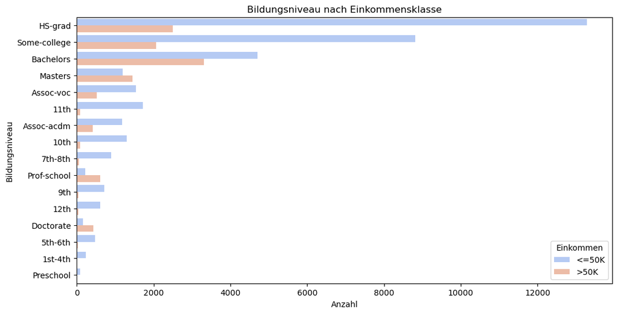

```python
plt.figure(figsize=(12,6))
sns.countplot(y="education", data=df, hue="income", order=df["education"].value_counts().index, palette="coolwarm")
plt.title("Bildungsniveau nach Einkommensklasse")
plt.xlabel("Anzahl")
plt.ylabel("Bildungsniveau")
plt.legend(title="Einkommen")
plt.show()
```

**Erkenntnisse aus der Einkommensverteilung nach Bildungsniveau**

Diese Visualisierung zeigt die Verteilung des Bildungsniveaus in Bezug auf die beiden Einkommensklassen (<=50K vs. >50K).

#### Familienstand nach Einkommensklasse

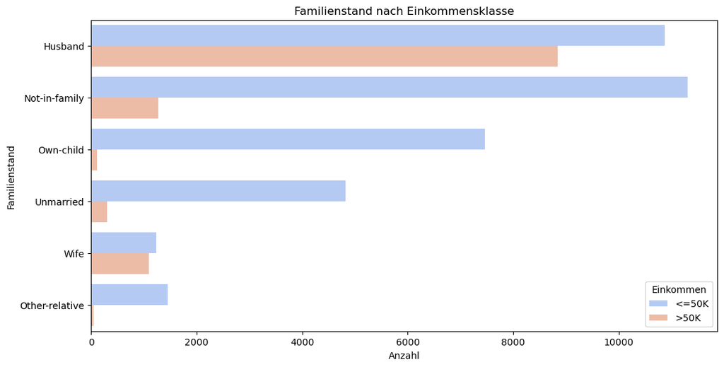

```python
plt.figure(figsize=(12,6))
sns.countplot(y="relationship", data=df, hue="income", order=df["relationship"].value_counts().index, palette="coolwarm")
plt.title("Familienstand nach Einkommensklasse")
plt.xlabel("Anzahl")
plt.ylabel("Familienstand")
plt.legend(title="Einkommen")
plt.show()
```

**Erkenntnisse aus der Einkommensverteilung nach Familienstand (Relationship)**

Diese Visualisierung zeigt, wie sich der Familienstand auf das Einkommen (<=50K vs. >50K) auswirkt.

#### Einkommensverteilung nach Familienstand

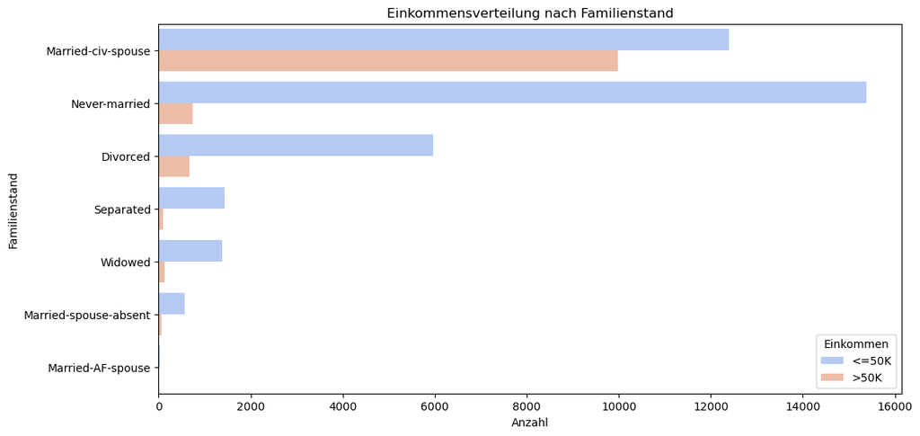

```python
plt.figure(figsize=(12,6))
sns.countplot(y="marital-status", data=df, hue="income", order=df["marital-status"].value_counts().index, palette="coolwarm")
plt.title("Einkommensverteilung nach Familienstand")
plt.xlabel("Anzahl")
plt.ylabel("Familienstand")
plt.legend(title="Einkommen", loc="lower right")
plt.show()
```

**Erkenntnisse aus der Einkommensverteilung nach Familienstand (marital-status)**

Diese Visualisierung zeigt die Verteilung des Familienstands in Bezug auf die Einkommensklassen (<=50K und >50K).

Wichtige Beobachtungen:

1. Verheiratete Personen („Married-civ-spouse“) haben die höchste Wahrscheinlichkeit für ein Einkommen >50K
- Diese Gruppe zeigt die größte Anzahl an Personen mit hohem Einkommen (>50K)
- Gleichzeitig gibt es auch viele Personen in dieser Kategorie mit einem Einkommen ≤50K, allerdings ist das Verhältnis zwischen hoher und niedrigerem Einkommen in dieser Gruppe ausgeglichener als bei anderen Kategorien
2. „Never-married“ Personen verdienen überwiegend ≤50K
- Diese Gruppe ist die zweitgrößte in der Verteilung
- Der Großteil der Nie-Verheirateten verdient ≤50K, nur ein kleiner Teil gehört zur höheren Einkommensklasse
- Dies könnte mit Faktoren wie Alter, weniger Berufserfahrung oder fehlender finanzieller Stabilität durch Partnerschaft zusammenhängen
3. Geschiedene („Divorced“), Getrennte („Separated“) und Verwitwete („Widowed“) verdienen größtenteils ≤50K
- Personen in diesen Kategorien haben nur einen sehr kleinen Anteil an Einkommen >50K
- Dies könnte mit finanziellen Belastungen durch Trennung oder dem Eintritt ins Rentenalter zusammenhängen
- Auch fehlende berufliche Entwicklungsmöglichkeiten nach Trennung oder Verlust eines Partners könnten eine Rolle spielen
4. „Married-spouse-absent“ und „Married-AF-spouse“ sind selten vertreten und verdienen überwiegend ≤50K
- „Married-spouse-absent“ bedeutet, dass die Person verheiratet ist, aber vom Partner getrennt lebt – diese Personen haben fast ausschließlich Einkommen ≤50K
- „Married-AF-spouse“ bedeutet, dass die Person mit jemandem im aktiven Militärdienst verheiratet ist – auch hier ist das Einkommen überwiegend ≤50K

#### Einkommensverteilung nach ethnischer Zugehörigkeit

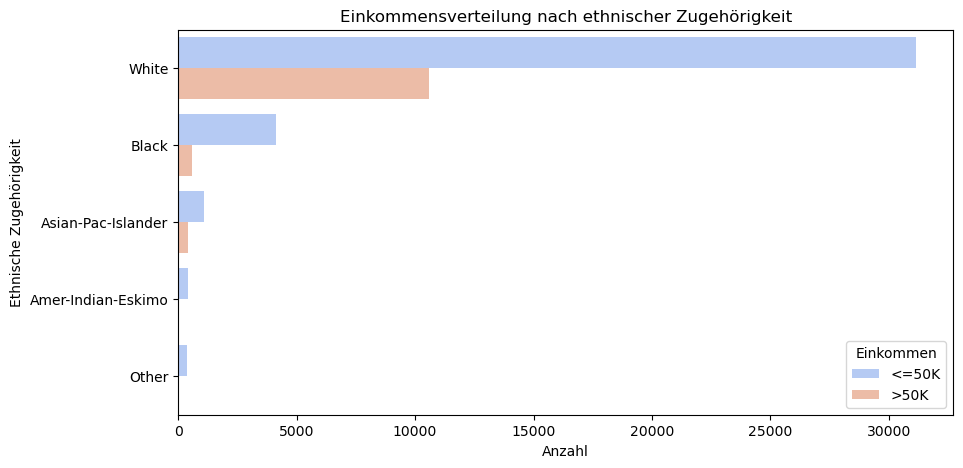

```python
plt.figure(figsize=(10,5))
sns.countplot(data=df, y="race", hue="income", order=df["race"].value_counts().index, palette="coolwarm")
plt.title("Einkommensverteilung nach ethnischer Zugehörigkeit")
plt.xlabel("Anzahl")
plt.ylabel("Ethnische Zugehörigkeit")
plt.legend(title="Einkommen")
plt.show()
```

**Erkenntnisse aus der Einkommensverteilung nach ethnischer Zugehörigkeit**

Diese Visualisierung zeigt die Verteilung der Einkommensklassen (<=50K und >50K) in Bezug auf die ethnische Zugehörigkeit der Personen im Datensatz.

#### Arbeitsverhältnis nach Branchen (workclass) und Einkommensklasse

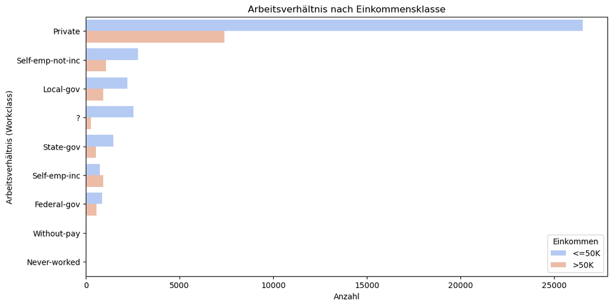

```python
plt.figure(figsize=(12,6))
sns.countplot(y="workclass", data=df, hue="income", order=df["workclass"].value_counts().index, palette="coolwarm")
plt.title("Arbeitsverhältnis nach Einkommensklasse")
plt.xlabel("Anzahl")
plt.ylabel("Arbeitsverhältnis (Workclass)")
plt.legend(title="Einkommen", loc="lower right")
plt.show()
```

**Erkenntnisse aus der Verteilung des Arbeitsverhältnisses (Workclass) nach Einkommensklasse**

Diese Visualisierung zeigt die Verteilung des Arbeitsverhältnisses (Workclass) in Bezug auf die Einkommensklassen (<=50K und >50K).

Wichtige Beobachtungen:

1. Die Mehrheit der Personen arbeitet im privaten Sektor („Private“)
- Die größte Gruppe ist der private Sektor, mit einem hohen Anteil an Personen mit ≤50K Einkommen
- Allerdings gibt es auch eine signifikante Anzahl von Personen im privaten Sektor mit Einkommen >50K, jedoch deutlich weniger als mit ≤50K
2. Selbstständige (Self-emp-not-inc & Self-emp-inc) haben höhere Anteile an Einkommen >50K
- Personen, die eingetragene Selbstständige („Self-emp-inc“) sind, haben einen vergleichsweise hohen Anteil an Einkommen >50K
- Nicht eingetragene Selbstständige („Self-emp-not-inc“) haben tendenziell geringere Einkommen, da die Mehrheit in dieser Gruppe ≤50K verdient
3. Regierungsangestellte („Local-gov“, „State-gov“, „Federal-gov“) haben eine ausgewogene Einkommensverteilung
- Personen, die für die Bundesregierung („Federal-gov“) arbeiten, haben im Verhältnis einen höheren Anteil an Einkommen >50K als die, die für kommunale oder Landesregierungen tätig sind
- Regierungsangestellte im Allgemeinen haben jedoch mehr Sicherheit und stabilere Einkommen
4. „Without-pay“ und „Never-worked“ haben fast ausschließlich Einkommen ≤50K
- Personen, die ohne Bezahlung arbeiten oder nie gearbeitet haben, gehören fast ausschließlich zur Einkommensklasse ≤50K
- Das ist wenig überraschend, da ein fehlendes Arbeitsverhältnis den Zugang zu hohem Einkommen stark einschränkt

#### Bildungsjahre nach Einkommensklasse

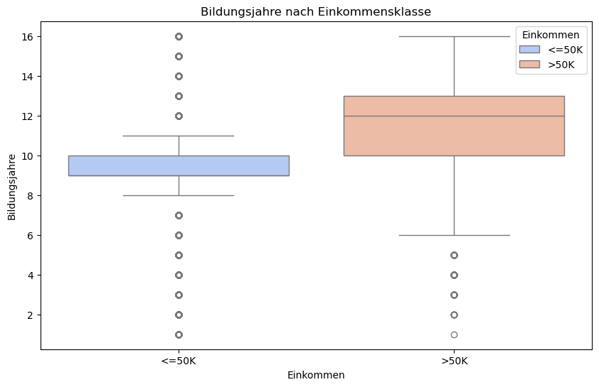

```python
# Sicherstellen, dass die Spalte 'income' als String gespeichert ist
df["income"] = df["income"].astype(str)

plt.figure(figsize=(10,6))
sns.boxplot(data=df, x="income", y="educational-num", hue="income", palette="coolwarm")

# Falls die Legende nicht automatisch erscheint, manuell setzen
plt.legend(title="Einkommen", labels=["<=50K", ">50K"])

plt.title("Bildungsjahre nach Einkommensklasse")
plt.xlabel("Einkommen")
plt.ylabel("Bildungsjahre")
plt.show()
```

**Erkenntnisse aus der Verteilung der Bildungsjahre nach Einkommensklasse**

Diese Visualisierung zeigt die Anzahl der Bildungsjahre (educational-num) für die beiden Einkommensklassen (<=50K und >50K) in einer Boxplot-Darstellung.

#### Bildungsjahre nach Einkommensklasse

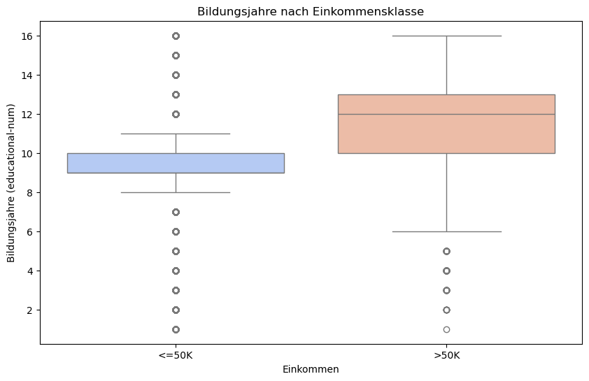

```python
# Boxplot für educational-num nach Einkommensklasse
plt.figure(figsize=(10,6))
sns.boxplot(data=df, x="income", y="educational-num", hue="income", palette="coolwarm", legend=False)

# Titel und Achsenbeschriftungen setzen
plt.title("Bildungsjahre nach Einkommensklasse")
plt.xlabel("Einkommen")
plt.ylabel("Bildungsjahre (educational-num)")

# Plot anzeigen
plt.show()
```

**Erkenntnisse aus der Verteilung der Bildungsjahre (educational-num) nach Einkommensklasse**

Diese Boxplot-Visualisierung zeigt, wie die Anzahl der Bildungsjahre (educational-num) mit der Einkommensklasse (<=50K vs. >50K) zusammenhängt.